# Lesson 7: Modeling heteroscedasticity

Last updated in April 2022

## Goals for Today

- Learn how to deal heteroscedasticity
- Learn how to deal with dependent errors

## Heteroskedasticity

## Heteroskedasticity

- Heteroskedasticity is relatively common, e.g. in bounded data.

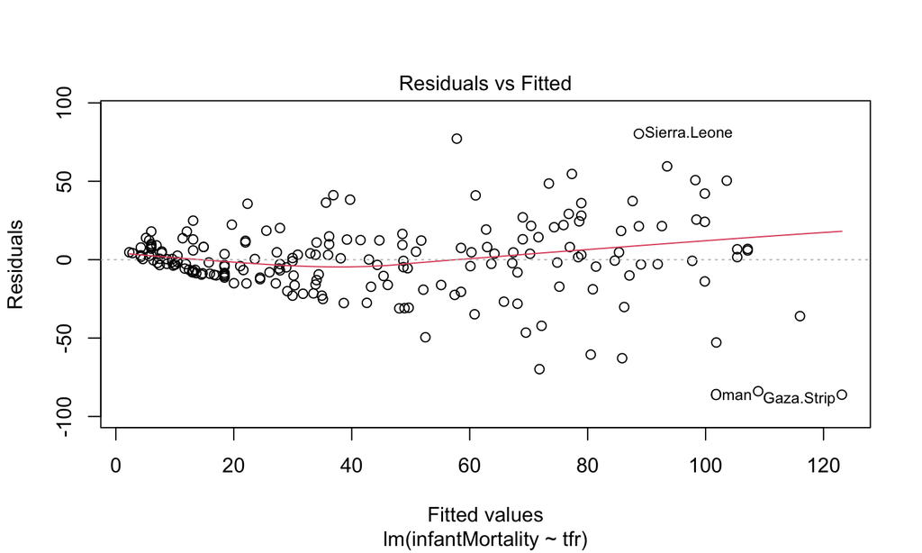

```r
mod1 = lm(infantMortality ~ tfr, data = un)
plot(mod1, which = 1)
```

## Effects of Heteroskedasticity

- When the assumption of homoscedasticity is broken two things will happen:
1. Regression coefficients’ estimates become less efficient.
2. Standard errors will be biased (usually too narrow confidence intervals, too low p values)
- To solve this, let’s remind ourself how variance works.

## When Homoscedasticity holds

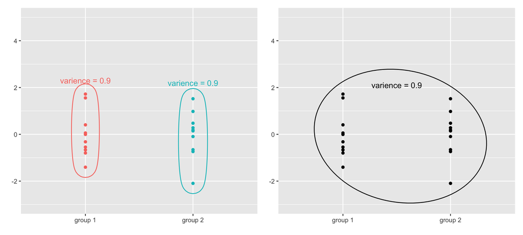

## When Homoscedasticity holds

- If we assume homoskedasticity, we can estimate variance of residuals for every value of x be computing variance of all residuals at once:

\[ SE_\beta = \frac{\sigma^2 \sum(x_i - \bar{x})^2}{[\sum(x_i - \bar{x})^2]^2} = \frac{\sigma^2}{\sum(x_i - \bar{x})^2} \]

- \(SE_\beta\) = Standard error of regression coefficient
- \(x_i\) = Observation *i* of the variable *x*
- \(\bar{x}\) = Mean value of *x*
- \(sigma^2\) = Variance of residuals

## Wild Heteroskedasticity Appears!

- What if the variances are not identical?

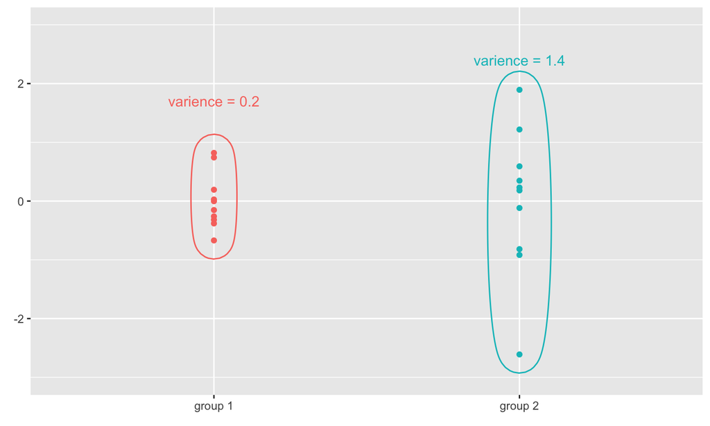

## Wild Heteroskedasticity Appears!

- The overall variance doesn’t match any single group.

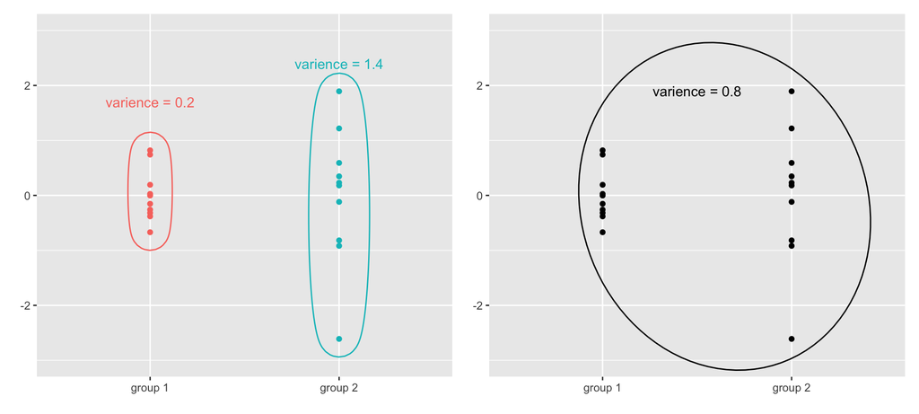

## Wild Heteroskedasticity Appears!

- If the assumption of homoscedasticity is violated, we cannot use the total residual variance as an estimate for individual levels.

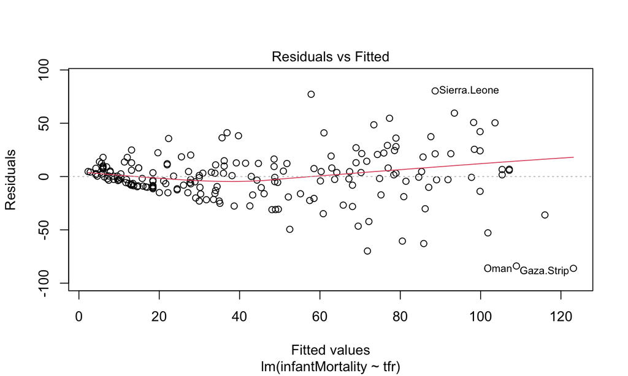

## Robust Standard Errors

- We simply go through the work of estimating residual variance for each level.
- From the classic formula:

\[ SE_\beta = \frac{\sigma^2 \sum(x_i - \bar{x})^2}{[\sum(x_i - \bar{x})^2]^2} \]

- To a new one **not** assuming homoscedasticity:

\[ SE_\beta = \frac{\sum(x_i - \bar{x})^2*\sigma_i^2}{[\sum(x_i - \bar{x})^2]^2} \]

## Robust Standard Errors

\[ SE_\beta = \frac{\sum(x_i - \bar{x})^2*\sigma_i^2}{[\sum(x_i - \bar{x})^2]^2} \]

- (Heteroscedastic) Robust Standard Error
- White’s Standard Error
- Sandwich Error
- HCO

## Variants of Robust Errors

- The previous formula is the original approach
- Works well in big samples, biased in small ones.
- Various corrections proposed:
  - HC1 (original correction, probably the worst one)
  - HC2
  - HC3

- in R all implemented in the `estimatr` package

## InteRmezzo!

## What Type of SE to use?

- For moderately large sample sizes (hundreds and more), little difference between HC1-HC3
- For very small samples (e.g. 30 observations), HC3 seems best

## Why Don’t Use Robust SE All the Time?

## Why Don’t Use Robust SE All the Time?

- Many economists will tell you to do so. But!
- For small samples, robust SE and tests based on them may be biased (especially, if homoscedasticity holds).
- Robust SE are less efficient.
- Violations of homoscedasticity may be sign of a missing predictor or misspecification.
- In practice, robust SE are very useful (and very underutilized in sociology), but not a panacea.

## Bonus: Clustered Standard Errors

## Clustered Standard Errors

- Linear regression assumes independece of errors.
- Can be violated because of repeated measurments, cluster based sampling, etc.
- Fortunately robust standard errors can help here (sometimes).
- Clustered Standard error estimates residual variance for each cluster separately.